# Briefing on package YGWLGiaoGiao

Xinwei Long

10/24/2019

## Introduction

The package YGWLGiaoGiao is mainly used for present summary and plots of American public yearly data regarding fatal injuries suffered in motor vehicle traffic crashes. Users can leverage the functions in the package to point to and read in CSV files containing crashes data across years from 2013 to 2015, see the summaries of occurence of crashes by month for certain year, and finally plot the spot of crashes trough importing package `maps()`.

Before using the functions in the package, you should first load in the necessary packages including the pacakge itself

```r
library(readr)
library(dplyr)
library(tidyr)
library(YGWLGiaoGiao)
```

## The `make_filename` function

This funcition can produce the file name of the dataset by only inputing year number, which serves as an intermediate function to `fars_read` function.

```r
year <- make_filename(2013)
year
```

```
## [1] "accident_2013.csv.bz2"
```

## The `fars_read` function

You may want to specify the name of CSV file containing data of certain year if you know one. Make sure you have downloaded the CSV files from link and set the current path to the dictionary where CSV files are stored.

```r
accident <- fars_read("accident_2013.csv.bz2")
accident %>% slice(1:5)
```

```
## # A tibble: 5 x 50
##   STATE ST_CASE VE_TOTAL VE_FORMS PVH_INVL  PEDS PERNOTMVIT PERMVIT PERSONS
##   <dbl>   <dbl>    <dbl>    <dbl>    <dbl> <dbl>      <dbl>   <dbl>   <dbl>
## 1     1   10001        1        1        0     0          0       8       8
## 2     1   10002        2        2        0     0          0       2       2
## 3     1   10003        1        1        0     0          0       1       1
## 4     1   10004        1        1        0     0          0       3       3
## 5     1   10005        2        2        0     0          0       3       3
## # ... with 41 more variables: COUNTY <dbl>, CITY <dbl>, DAY <dbl>,
## #   MONTH <dbl>, YEAR <dbl>, DAY_WEEK <dbl>, HOUR <dbl>, MINUTE <dbl>,
## #   NHS <dbl>, ROAD_FNC <dbl>, ROUTE <dbl>, TWAY_ID <chr>, TWAY_ID2 <chr>,
## #   MILEPT <dbl>, LATITUDE <dbl>, LONGITUD <dbl>, SP_JUR <dbl>,
## #   HARM_EV <dbl>, MAN_COLL <dbl>, RELJCT1 <dbl>, RELJCT2 <dbl>,
## #   TYP_INT <dbl>, WRK_ZONE <dbl>, REL_ROAD <dbl>, LGT_COND <dbl>,
## #   WEATHER1 <dbl>, WEATHER2 <dbl>, WEATHER <dbl>, SCH_BUS <dbl>,
## #   RAIL <chr>, NOT_HOUR <dbl>, NOT_MIN <dbl>, ARR_HOUR <dbl>,
## #   ARR_MIN <dbl>, HOSP_HR <dbl>, HOSP_MN <dbl>, CF1 <dbl>, CF2 <dbl>,
## #   CF3 <dbl>, FATALS <dbl>, DRUNK_DR <dbl>
```

Practically, this function serves an intermediate function to `fars_read_years` and `fars_map_state` functions.

## The `fars_read_years` function

You can input a integer vector containing years of dataset. This function then prepare the list of tibbles by year for the function `fars_summarize_years`

```r
years <- c(2013,2014,2015)
fars_read_years(years)[[1]]
```

```
## # A tibble: 30,202 x 2
##    MONTH  year
##    <dbl> <dbl>
##  1     1  2013
##  2     1  2013
##  3     1  2013
##  4     1  2013
##  5     1  2013
##  6     1  2013
##  7     1  2013
##  8     1  2013
##  9     1  2013
## 10     1  2013
## # ... with 30,192 more rows
```

## The `fars_summarize` function

This function can present the monthly occurence of crashes for a specific year. To illustrate how to use this function, please check the example below:

Initiate the years vector and input it in `fars_summarize`, the result is preseted in a tibble

```r
fars_summarize_years(years)
```

```
## # A tibble: 12 x 4
##    MONTH `2013` `2014` `2015`
##    <dbl>  <int>  <int>  <int>
##  1     1   2230   2168   2368
##  2     2   1952   1893   1968
##  3     3   2356   2245   2385
##  4     4   2300   2308   2430
##  5     5   2532   2596   2847
##  6     6   2692   2583   2765
##  7     7   2660   2696   2998
##  8     8   2899   2800   3016
##  9     9   2741   2618   2865
## 10    10   2768   2831   3019
## 11    11   2615   2714   2724
## 12    12   2457   2604   2781
```

## The `fars_map_state` function

By importing the function `map` from `maps`, you can plot the spot of crashes of certain year for one state in US. To do this, you need two inputs `state.num`, which specifies the state number, and `year`. If you want to plot the spot of crashes in 2013 for Alabama, we can run the folloing code:

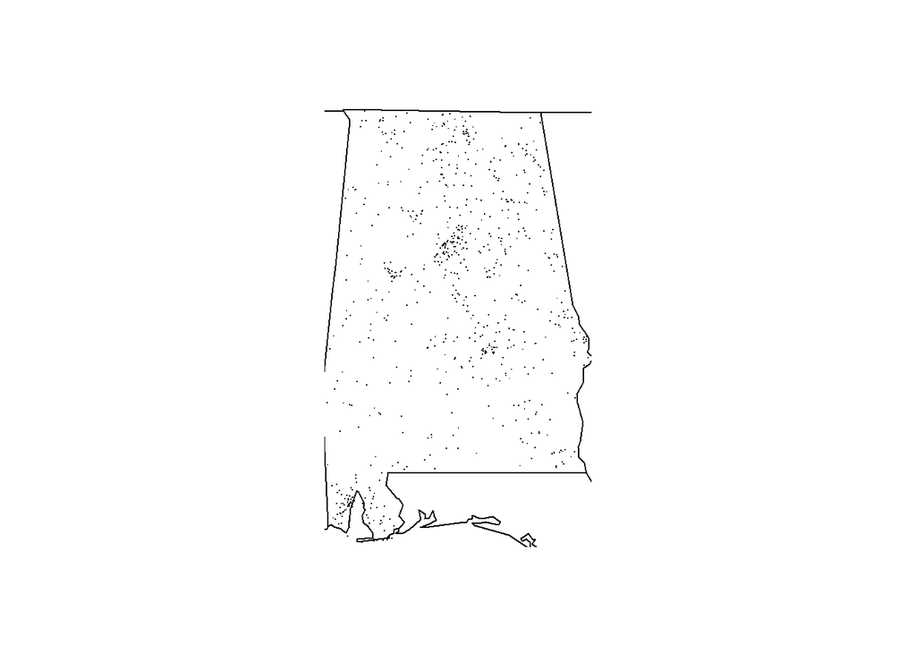

```r
year <- 2013
state.num <- "1"
fars_map_state(state.num, year)
```